# Ecology Data Tidying

Keith Post

6/24/2021

## **Summary**

### Description of raw data

The following describe the raw data collected and units of measure:

- Grasshoppers
  - Number of grasshoppers counted per plot for each date
- Aboveground plant biomass (measures for each plot)
  - Mass of plant + bag + washers (g)
  - Mass of bag + washers (g)
  - Mass of plants directly measured (g) (note: some plots had directly measured biomass)
  - Mass of functional groups (g)
    - Other grasses (g) (i.e., grasses other than fescue)
    - Forbs (g)
    - Shrubs (g)
- Belowground plant biomass
  - Crucible number
  - Crucible mass (g)
  - Crucible + plant (g)
  - Crucible + ash (g)
- Soil (for start and end of experiment)
  - Soil can #
  - Soil for microbial extraction (g)
  - Soil for nematode extraction (g)
  - Empty can + lid (g)
  - Soil for moisture determination (g)
  - Soil can + lid + dried soil (g)
  - Mite sample soil + bag (g)
  - Mite sample bag only (g)
- Soil nematodes (for each plot at start and end of experiment)
  - Numbers of each feeding group (in a 200-nematode subsample)
    - Bacterial feeders (BF)
    - Fungal feeders (FF)
    - Plant parasites (PP)
    - Omnivores (OM)
    - Predators (PR)
    - Unknowns (UNK)
  - Total nematodes (TOTAL)
- Soil microarthropods (or each plot at start and end of experiment)
  - Numbers of different groups
    - Fungal-feeding mites (FF)
    - Predatory mites (PR)
    - Springtails (SPR)
    - Other arthropods (ARTH)
  - Total arthropods (TOTAL)

### Summary of tidying process

This data project outlines the steps involved in preprocessing the raw data (described above) for statistical analyses primarily using tidyverse and tidyverse-adjacent R packages. The data tidying was separated into three parts/groups: 1) grasshopper, 2) plant biomass, and 3) soil and soil animal data. In general, the following steps were completed for each part: 1) R packages loaded, 2) data importation, 3) data checking (e.g., dimensions, column classes, n’s, range of values), 4) data cleaning (e.g., eliminating columns, renaming columns), 5) missing data assessment, 6) reclassifying variables (e.g., changing variable classes, deriving a variable of interest from two or more pieces of raw data), and 7) writing (saving) tidied data.

## **Grasshopper tidying**

The relevant packages was loaded into R. The function read_xlsx() from the readxl package was used to import the data from an Excel file to R.

```r
#load packages
library(here)
library(readxl)
library(janitor)
library(lubridate)
library(tidyr)
library(visdat)
library(skimr)
library(readr)

#data import
gh<-read_xlsx(here("data","raw_data","field_expt_gh.xlsx"),col_names=TRUE)
head(gh) #dates got mangled during read-in
```

[output not shown]

The data cleaning focused on column names as these did not transfer well from Excel. Names only in lowercase and without spaces was the approach for this dataset as well as the whole project. This is easily done with clean_names() in the janitor package. The dates were also changed by creating a vector and using base R.

```r
#clean_names
gh<-clean_names(gh)
#create date vector
dates<-c("2014-09-13","2014-09-19","2014-09-26","2014-10-03","2014-10-10",
         "2014-10-16","2014-10-21")
#replace date headers with it
names(gh)[3:9]<-dates
```

Grasshopper data were reshaped from wide to long format using pivot_longer() in tidyr, and three variables were re-classified.

```r
#convert to wide format
gh<-gh %>% pivot_longer(cols=3:9,names_to="date",values_to="number")
#reclassify variables
gh$trmt<-as.factor(gh$trmt)
gh$date<-ymd(gh$date)
gh$number<-as.integer(gh$number)

tidy_gh<-gh
```

The tibble was renamed to tidy_gh following these initial cleaning steps.

The data were checked by assessing numbers of rows and columns and levels of the factor trmt and previewing parts of the data for any irregularities.

```r
nrow(tidy_gh); ncol(tidy_gh) #check # of rows/cols; 84=12 (plots) * 7 (dates)
```

```
## [1] 84
```

```
## [1] 4
```

```r
str(tidy_gh) #check classes of variables; they check out
```

```
## tibble [84 × 4] (S3: tbl_df/tbl/data.frame)
##  $ plot  : num [1:84] 1 1 1 1 1 1 1 2 2 2 ...
##  $ trmt  : Factor w/ 2 levels "Ex","Gh": 2 2 2 2 2 2 2 1 1 1 ...
##  $ date  : Date[1:84], format: "2014-09-13" "2014-09-19" ...
##  $ number: int [1:84] 1 0 2 0 0 0 1 0 1 1 ...
```

```r
levels(tidy_gh$trmt) #check factor levels; they check out
```

```
## [1] "Ex" "Gh"
```

```r
head(tidy_gh,n=10); tail(tidy_gh,n=10) #check top/bottom of tibble
```

```
## # A tibble: 10 x 4
##     plot trmt  date       number
##    <dbl> <fct> <date>      <int>
##  1     1 Gh    2014-09-13      1
##  2     1 Gh    2014-09-19      0
##  3     1 Gh    2014-09-26      2
##  4     1 Gh    2014-10-03      0
##  5     1 Gh    2014-10-10      0
##  6     1 Gh    2014-10-16      0
##  7     1 Gh    2014-10-21      1
##  8     2 Ex    2014-09-13      0
##  9     2 Ex    2014-09-19      1
## 10     2 Ex    2014-09-26      1
```

```
## # A tibble: 10 x 4
##     plot trmt  date       number
##    <dbl> <fct> <date>      <int>
##  1    11 Gh    2014-10-10      0
##  2    11 Gh    2014-10-16      0
##  3    11 Gh    2014-10-21      2
##  4    12 Ex    2014-09-13      0
##  5    12 Ex    2014-09-19      0
##  6    12 Ex    2014-09-26      0
##  7    12 Ex    2014-10-03      1
##  8    12 Ex    2014-10-10      0
##  9    12 Ex    2014-10-16      0
## 10    12 Ex    2014-10-21      0
```

No issues were found.

Missing data were assessed visually using vis_dat(0) from the visdat package.

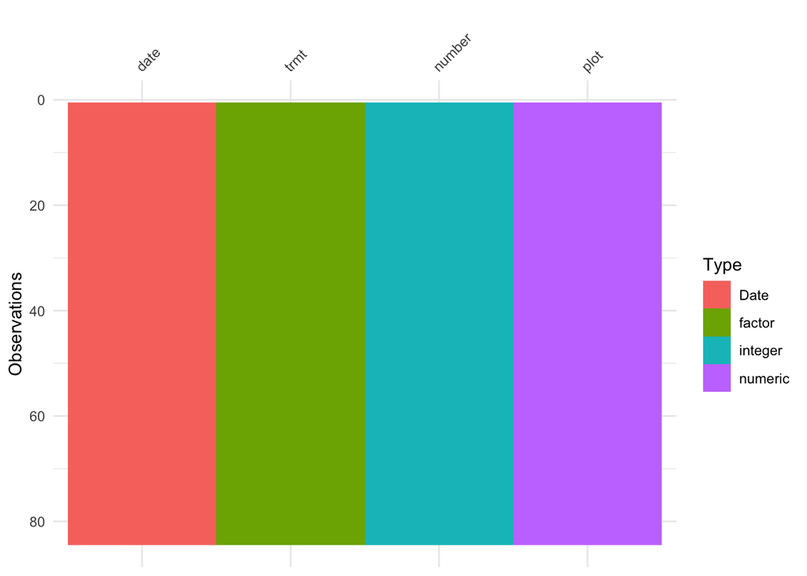

```r
vis_dat(tidy_gh)
```

No missing data were detected, and variable classes were correct.

Grasshopper data were checked once again.

```r
#check n's (using prior knowledge)
range(tidy_gh$date) #2014-09-13 to 2014-10-21, which are correct range of dates
```

```
## [1] "2014-09-13" "2014-10-21"
```

```r
range(tidy_gh$number) #0-2, which is correct
```

```
## [1] 0 2
```

The date and grasshopper count ranges were correct and reasonable, respectively.

The tidied grasshopper data were saved as a .csv.

```r
write_csv(tidy_gh,here("data","tidy_data","tidy_gh_data.csv"))
```

## **Plant biomass tidying**

The packages need for working with these data were loaded and the data for aboveground plant biomass, aboveground plant biomass by functional group, and belowground plant biomass were read into R. Note that there are duplicate packages loaded across this project as each part would be considered a separate R script.

```r
#load packages
library(here)
library(readxl)
library(tidyr)
library(dplyr)
library(janitor)
library(forcats)
library(purrr)
library(visdat)
library(skimr)
library(readr)

#data import
ag_plant<-read_xlsx(here("data","raw_data","field_expt_plant.xlsx"),col_names=TRUE,
                    sheet="Aboveground-total")

ag_plant_groups<-read_xlsx(here("data","raw_data","field_expt_plant.xlsx"),col_names=TRUE,
                           sheet="Aboveground-functional groups")

bg_plant<-read_xlsx(here("data","raw_data","field_expt_plant.xlsx"),col_names=TRUE,
                    sheet="Belowground-new")
```

### Aboveground plant biomass

Preliminary data checking, similar to the grasshopper data, was run on both tibbles.

```r
#preliminary data checking
dim(ag_plant) #check 34 x 5, which seems correct
```

```
## [1] 34  5
```

```r
str(ag_plant) #check classes of variables; need to change some eventually
```

```
## tibble [34 × 5] (S3: tbl_df/tbl/data.frame)
##  $ Plot #                                   : num [1:34] 1 NA NA NA 2 NA NA NA 3 NA ...
##  $ Bag #                                    : num [1:34] 1 2 3 4 1 2 3 4 1 2 ...
##  $ Mass of biomass + bag + washers (if nec.): num [1:34] NA 32.4 32.8 19.7 36.4 ...
##  $ Mass of bag + washers (if nec.)          : num [1:34] NA 6.79 6.99 6.96 6.87 6.81 6.66 6.89 6.86 6.7 ...
##  $ Measured biomass (g)                     : num [1:34] 19.7 NA NA NA NA ...
```

```r
head(ag_plant,n=10); tail(ag_plant,n=10) #preview data--need to fill; other NAs expected
```

```
## # A tibble: 10 x 5
##    `Plot #` `Bag #` `Mass of biomass + ba… `Mass of bag + was… `Measured biomas…
##       <dbl>   <dbl>                  <dbl>               <dbl>             <dbl>
##  1        1       1                   NA                 NA                 19.7
##  2       NA       2                   32.4                6.79              NA
##  3       NA       3                   32.8                6.99              NA
##  4       NA       4                   19.7                6.96              NA
##  5        2       1                   36.4                6.87              NA
##  6       NA       2                   22.0                6.81              NA
##  7       NA       3                   22.6                6.66              NA
##  8       NA       4                   27.3                6.89              NA
##  9        3       1                   36.2                6.86              NA
## 10       NA       2                   25.9                6.7               NA
```

```
## # A tibble: 10 x 5
##    `Plot #` `Bag #` `Mass of biomass + ba… `Mass of bag + was… `Measured biomas…
##       <dbl>   <dbl>                  <dbl>               <dbl>             <dbl>
##  1        8       1                   58.3                33.3              NA
##  2       NA       2                   68.1                34.1              NA
##  3        9       1                   53.1                26.2              NA
##  4       NA       2                   63.9                29.2              NA
##  5       10       1                   61.0                28.5              32.4
##  6       NA       2                   65.2                33.3              32.0
##  7       11       1                   86.6                48.7              37.9
##  8       NA       2                   62.6                31.7              30.8
##  9       12       1                   58.6                33.0              25.6
## 10       NA       2                   61.7                36.0              25.7
```

```r
dim(ag_plant_groups) #12 x 4; 12 plots and 4 variables
```

```
## [1] 12  4
```

```r
str(ag_plant_groups) #check classes of variables; need to change plot # eventually
```

```
## tibble [12 × 4] (S3: tbl_df/tbl/data.frame)
##  $ Plot #          : num [1:12] 1 2 3 4 5 6 7 8 9 10 ...
##  $ Other grasses(g): num [1:12] 4.55 6.47 3.74 4.46 3.05 2.36 5.78 1.99 4.26 2.77 ...
##  $ Forbs (g)       : num [1:12] 0 0.154 1.288 0 1.761 ...
##  $ Shrubs (g)      : num [1:12] 0 0 0 0 0 0 0 0.12 0 0 ...
```

```r
ag_plant_groups #data look fine
```

```
## # A tibble: 12 x 4
##    `Plot #` `Other grasses(g)` `Forbs (g)` `Shrubs (g)`
##       <dbl>              <dbl>       <dbl>        <dbl>
##  1        1               4.55       0             0
##  2        2               6.47       0.154         0
##  3        3               3.74       1.29          0
##  4        4               4.46       0             0
##  5        5               3.05       1.76          0
##  6        6               2.36       0.126         0
##  7        7               5.78       0.296         0
##  8        8               1.99       0.338         0.12
##  9        9               4.26       0             0
## 10       10               2.77       0.208         0
## 11       11               5.77       0.302         0
## 12       12               4.28       0             0
```

Some variable classes needed to be changed. Plot values were missing for some rows, and missing data were detected.

The column names for the aboveground plant biomass tibble were cleaned by manually renaming them, while clean_names() was run on the functional group tibble. The missing plot values were addressed using fill() from the tidyr package.

```r
#create character vector of col names
ag_plant_names<-c("plot","bag","biomass_bag_washers_g","bag_washers_g","measured_biomass_g")
names(ag_plant)<-ag_plant_names #append to tibble

ag_plant_groups<-clean_names(ag_plant_groups)

#fill in empty cells
ag_plant<-fill(ag_plant,plot)
```

Aboveground plant biomass was calculated for some plots using mutate(), and an algorithm to select this measure or directly measured biomass was run on the data. Variables were reclassified, and plant biomass was determined for each plot.

```r
#rename, compute, eliminate, and reclassify variables
#compute 'calculated' biomass from subtraction
ag_plant<-ag_plant %>%
  mutate(calc_biomass_g=biomass_bag_washers_g-bag_washers_g) #calculate biomass
ag_plant$calc_biomass_g[29:34]<-NA #replace values with NA where biomass directly measured
#create algorithm where ag_biomass is based on directly measured or computed biomass
ag_plant<-ag_plant %>%
  mutate(ag_biomass_g=ifelse(!is.na(measured_biomass_g),measured_biomass_g,calc_biomass_g))
#reclassify variables
ag_plant[1:2]<-map(ag_plant[1:2],as.integer) #convert plot and bag cols to integers
#sum by plot
ag_plant_by_plot<-ag_plant %>%
  group_by(plot) %>%
  summarize(tot_ag_biomass_g=sum(ag_biomass_g)) %>%
  ungroup() %>%
  mutate(trmt=ifelse(plot %in% c(1,3,5,8,9,11),"Gh","Ex")) #add treatment col

#rename and reclassify cols
ag_plant_by_plot$trmt<-as.factor(ag_plant_by_plot$trmt)
names(ag_plant_groups)[1]<-"plot"
ag_plant_groups$plot<-as.integer(ag_plant_groups$plot)
```

The two tibbles–aboveground plant biomass and functional group biomass–were joined by plot, fescue biomass column created, and some columns renamed. Plant biomass was converted to biomass density (g/m^2) by dividing biomass by the area of remaining soil surface in each plot (i.e., 0.5 m^2 plot - area removed by soil sampling).

```r
#join ag plant tibbles, create fescue biomass col, and convert biomass to g/m2
ag_plant_biomass<-inner_join(ag_plant_by_plot,ag_plant_groups,by="plot") %>%
  mutate(fescue_biomass=tot_ag_biomass_g-(other_grasses_g+forbs_g+shrubs_g)) %>% #create fescue col
  select(plot,trmt,fescue_biomass,other_grasses_g,forbs_g,shrubs_g,tot_ag_biomass_g) %>% #reorder using select
  mutate(across(fescue_biomass:tot_ag_biomass_g,~.x/0.49487)) #convert to biomass per m^2

#rename cols
ag_plant_dens_names<-c("fescue_biomass_g_m2","oth_grasses_g_m2","forbs_g_m2",
                       "shrubs_g_m2","tot_ag_plant_g_m2")
names(ag_plant_biomass)[3:7]<-ag_plant_dens_names
```

### Belowground plant biomass

As done with grasshopper and aboveground plant biomass data, root biomass data were visually inspected and checked for numbers of rows and columns and types of variables. The column names were cleaned using clean_names().

```r
#preliminary data check
dim(bg_plant) #check 45 x 7: indicates some missing rows (as a multiple of 12 expected)
```

```
## [1] 45  7
```

```r
str(bg_plant) #check classes of variables; some need to change some eventually
```

```
## tibble [45 × 7] (S3: tbl_df/tbl/data.frame)
##  $ Plot #              : num [1:45] 1 2 3 4 5 6 7 8 9 10 ...
##  $ Location            : chr [1:45] "B" "B" "B" "B" ...
##  $ Depth (cm)          : chr [1:45] "0-10" "0-10" "0-10" "0-10" ...
##  $ Crucible #          : chr [1:45] "653" "B4" "B6" "B5" ...
##  $ Crucible (g)        : num [1:45] 44.9 56.6 50.1 55.7 55 ...
##  $ Crucible + plant (g): num [1:45] 53.6 65.2 55.9 62.8 59.7 ...
##  $ Crucible + ash (g)  : num [1:45] 50.9 63.3 54.5 61.4 58.4 ...
```

```r
head(bg_plant,n=10); tail(bg_plant,n=10) #seems like plots 1 & 2 for location P are missing
```

```
## # A tibble: 10 x 7
##    `Plot #` Location `Depth (cm)` `Crucible #` `Crucible (g)` `Crucible + pla…
##       <dbl> <chr>    <chr>        <chr>                 <dbl>            <dbl>
##  1        1 B        0-10         653                    44.9             53.6
##  2        2 B        0-10         B4                     56.6             65.2
##  3        3 B        0-10         B6                     50.1             55.9
##  4        4 B        0-10         B5                     55.7             62.8
##  5        5 B        0-10         B8                     55.0             59.7
##  6        6 B        0-10         2                      55.8             57.5
##  7        7 B        0-10         90                     48.7             54.8
##  8        8 B        0-10         615                    44.7             49.3
##  9        9 B        0-10         642                    43.6             45.7
## 10       10 B        0-10         B7                     54.4             58.3
## # … with 1 more variable: `Crucible + ash (g)` <dbl>
```

[output not shown]

```r
#clean and view names
bg_plant<-clean_names(bg_plant)
```

Some variables have inappropriate classes, and missing data were detected.

Root biomass for each location (i.e., bare (B) or plant-covered (P)) and depth (i.e., 0-10, 10-20 cm) were computed and converted to density by scaling up the area of the soil core to 1 m^2. Exclosure treatment was added to each row, and three rows which had missing data were added as well.

```r
#compute root biomass and root biomass density
bg_plant_biomass<-bg_plant %>%
  rename(plot=plot_number) %>%
  mutate(trmt=ifelse(plot %in% c(1,3,5,8,9,11),"Gh","Ex")) %>% #assign trmts
  mutate(root_g_m2=(crucible_plant_g-crucible_ash_g)*315.764039) %>% #calculate root biomass & convert to g/m^2
  select(plot,trmt,location,depth_cm,root_g_m2) %>%
  add_row(plot=c(1,1,2),trmt=c("Gh","Gh","Ex"),location=c("B","P","P"), #add NAs
          depth_cm=c("10-20","10-20","10-20"),root_g_m2=rep(NA,3)) %>%
  arrange(plot,location,depth_cm) #sort data
bg_plant_biomass
```

```
## # A tibble: 48 x 5
##     plot trmt  location depth_cm root_g_m2
##    <dbl> <chr> <chr>    <chr>        <dbl>
##  1     1 Gh    B        0-10          831.
##  2     1 Gh    B        10-20          NA
##  3     1 Gh    P        0-10          366.
##  4     1 Gh    P        10-20          NA
##  5     2 Ex    B        0-10          579.
##  6     2 Ex    B        10-20         205.
##  7     2 Ex    P        0-10          362.
##  8     2 Ex    P        10-20          NA
##  9     3 Gh    B        0-10          457.
## 10     3 Gh    B        10-20         140.
## # … with 38 more rows
```

The tibble now has 48 rows (instead of 45 rows), which is correct because there are 12 plots x 2 locations x 2 depths.

Select variables were reclassified and the depth_cm factor levels renamed.

```r
#reclassify variables
bg_plant_biomass$plot<-as.integer(bg_plant_biomass$plot)
bg_plant_biomass[2:4]<-map(bg_plant_biomass[2:4],as.factor)
bg_plant_biomass$depth_cm<-fct_recode(bg_plant_biomass$depth_cm,`10`="0-10",`20`="10-20")
#recode depth levels to make it easier
```

### Shoot:root biomass calculation and tidying

The ratio of shoot biomass to root biomass (known as shoot:root) was calculated using aboveground biomass density and the density of root biomass using 0-20 cm depth. This process included summing root biomass density across location and depth and dividing by two (to account for two soil cores per plot). Shoot:root was computed.

```r
#sum and avg root biomass for each plot
tot_root_biomass<-bg_plant_biomass %>%
  group_by(plot,trmt) %>%
  summarize(tot_root_g_m2=sum(root_g_m2/2)) #take average value based on bare and plant locations

#compute s:r data
s_r_data<-bind_cols(ag_plant_biomass[c(1,2,7)],tot_root_biomass[3]) %>%
  mutate(s_r=tot_ag_plant_g_m2/tot_root_g_m2)
```

Missing data for the three tibbles (i.e., aboveground biomass, belowground biomass, shoot:root) were assessed visually, and the tibbles were checked for any irregularities in their values.

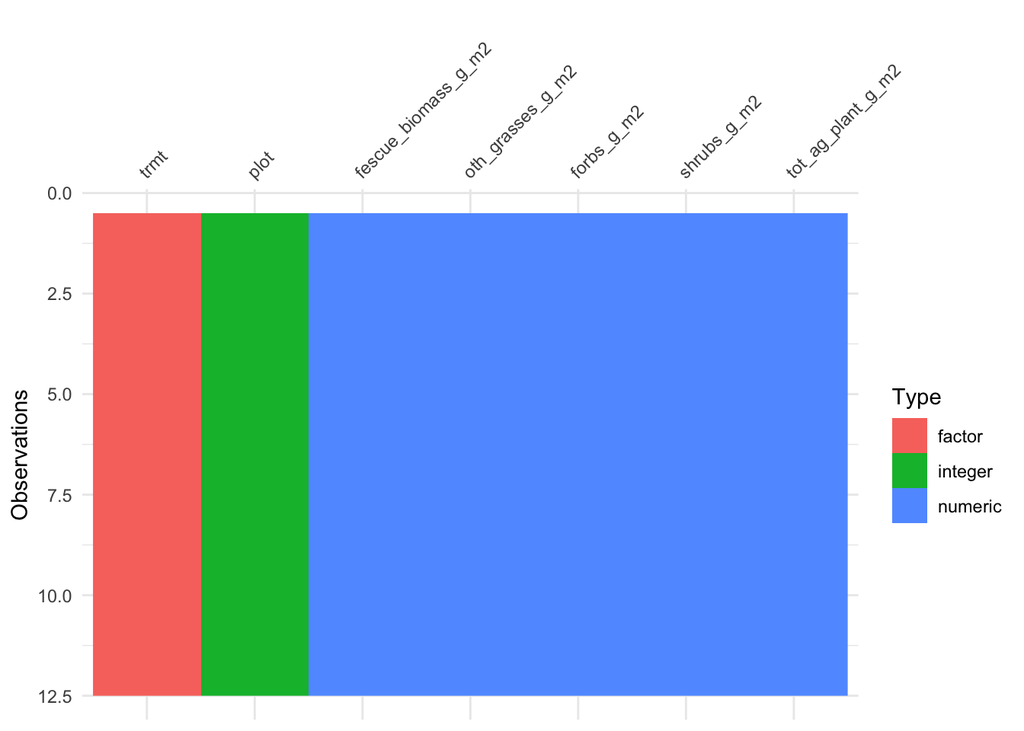

```r
#missing data assessment
vis_dat(ag_plant_biomass) #0 NAs
```

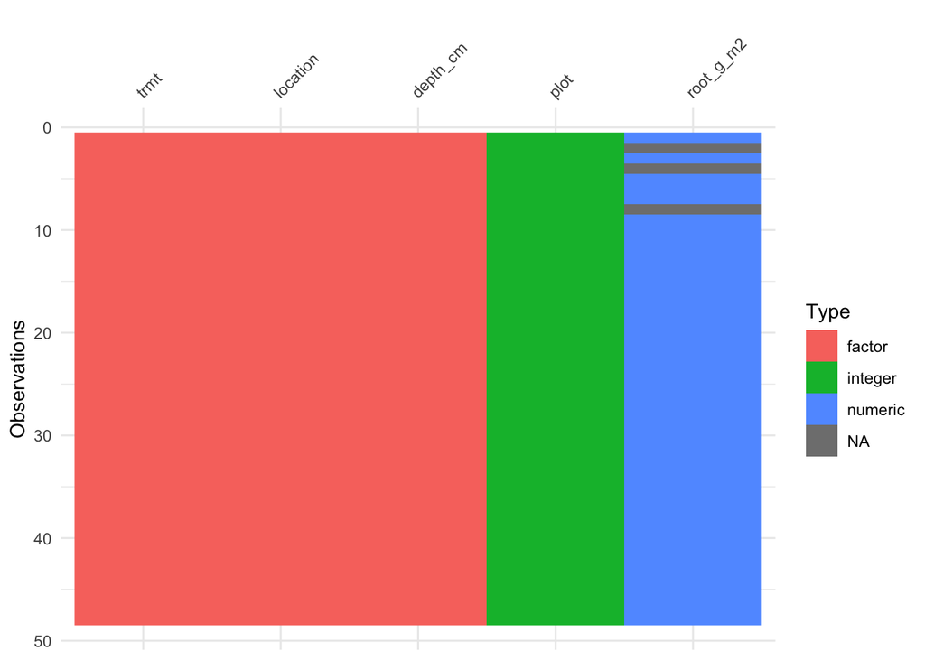

```r
vis_dat(bg_plant_biomass) #3 NAs; expected
```

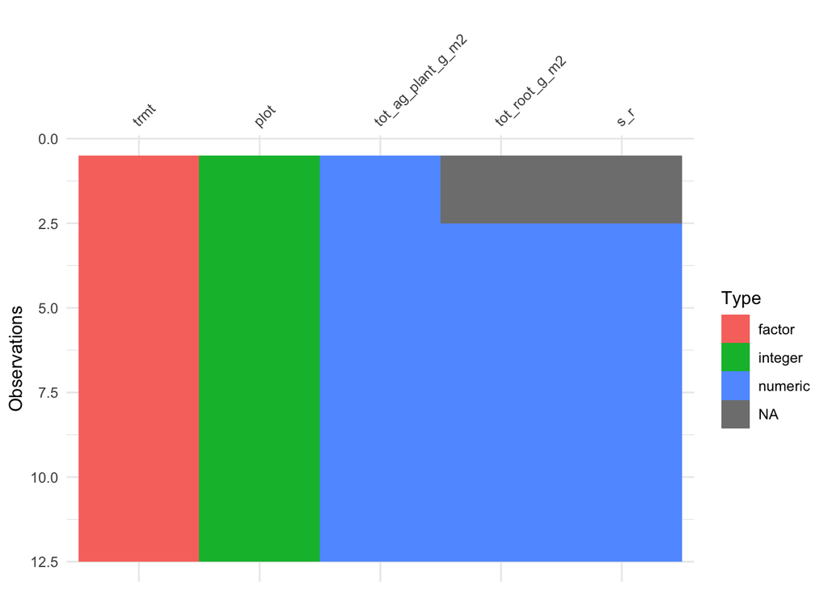

```r
vis_dat(s_r_data) #2 cols with a few values each
```

```r
#missing data expected

#checking data for irregularities
dim(ag_plant_biomass); dim(bg_plant_biomass); dim(s_r_data) #all seem fine
```

```
## [1] 12  7
```

```
## [1] 48  5
```

```
## [1] 12  5
```

```r
str(ag_plant_biomass); str(bg_plant_biomass); str(s_r_data) #all cols coded correctly
```

```
## tibble [12 × 7] (S3: tbl_df/tbl/data.frame)
##  $ plot               : int [1:12] 1 2 3 4 5 6 7 8 9 10 ...
##  $ trmt               : Factor w/ 2 levels "Ex","Gh": 2 1 2 1 2 1 1 2 2 1 ...
##  $ fescue_biomass_g_m2: num [1:12] 160 150 193 138 140 ...
##  $ oth_grasses_g_m2   : num [1:12] 9.19 13.07 7.56 9.01 6.16 ...
##  $ forbs_g_m2         : num [1:12] 0 0.311 2.603 0 3.559 ...
##  $ shrubs_g_m2        : num [1:12] 0 0 0 0 0 ...
##  $ tot_ag_plant_g_m2  : num [1:12] 169 164 203 147 150 ...
```

```
## tibble [48 × 5] (S3: tbl_df/tbl/data.frame)
##  $ plot     : int [1:48] 1 1 1 1 2 2 2 2 3 3 ...
##  $ trmt     : Factor w/ 2 levels "Ex","Gh": 2 2 2 2 1 1 1 1 2 2 ...
##  $ location : Factor w/ 2 levels "B","P": 1 1 2 2 1 1 2 2 1 1 ...
##  $ depth_cm : Factor w/ 2 levels "10","20": 1 2 1 2 1 2 1 2 1 2 ...
##  $ root_g_m2: num [1:48] 831 NA 366 NA 579 ...
```

```
## tibble [12 × 5] (S3: tbl_df/tbl/data.frame)
##  $ plot             : int [1:12] 1 2 3 4 5 6 7 8 9 10 ...
##  $ trmt             : Factor w/ 2 levels "Ex","Gh": 2 1 2 1 2 1 1 2 2 1 ...
##  $ tot_ag_plant_g_m2: num [1:12] 169 164 203 147 150 ...
##  $ tot_root_g_m2    : num [1:12] NA NA 647 585 623 ...
##  $ s_r              : num [1:12] NA NA 0.315 0.252 0.24 ...
```

```r
ag_plant_biomass
```

```
## # A tibble: 12 x 7
##     plot trmt  fescue_biomass_… oth_grasses_g_m2 forbs_g_m2 shrubs_g_m2
##    <int> <fct>            <dbl>            <dbl>      <dbl>       <dbl>
##  1     1 Gh               160.              9.19      0           0
##  2     2 Ex               150.             13.1       0.311       0
##  3     3 Gh               193.              7.56      2.60        0
##  4     4 Ex               138.              9.01      0           0
##  5     5 Gh               140.              6.16      3.56        0
##  6     6 Ex               108.              4.77      0.255       0
##  7     7 Ex               163.             11.7       0.598       0
##  8     8 Gh               114.              4.02      0.683       0.242
##  9     9 Gh               116.              8.61      0           0
## 10    10 Ex               124.              5.60      0.420       0
## 11    11 Gh               127.             11.7       0.610       0
## 12    12 Ex                95.0             8.65      0           0
## # … with 1 more variable: tot_ag_plant_g_m2 <dbl>
```

```r
s_r_data
```

```
## # A tibble: 12 x 5
##     plot trmt  tot_ag_plant_g_m2 tot_root_g_m2    s_r
##    <int> <fct>             <dbl>         <dbl>  <dbl>
##  1     1 Gh                 169.           NA  NA
##  2     2 Ex                 164.           NA  NA
##  3     3 Gh                 203.          647.  0.315
##  4     4 Ex                 147.          585.  0.252
##  5     5 Gh                 150.          623.  0.240
##  6     6 Ex                 113.          436.  0.259
##  7     7 Ex                 175.          668.  0.262
##  8     8 Gh                 119.          370.  0.322
##  9     9 Gh                 124.          597.  0.209
## 10    10 Ex                 130.          544.  0.239
## 11    11 Gh                 139.          419.  0.331
## 12    12 Ex                 104.          489.  0.212
```

```r
head(bg_plant_biomass,n=10); tail(bg_plant_biomass,n=10) #look as expected
```

```
## # A tibble: 10 x 5
##     plot trmt  location depth_cm root_g_m2
##    <int> <fct> <fct>    <fct>        <dbl>
##  1     1 Gh    B        10            831.
##  2     1 Gh    B        20             NA
##  3     1 Gh    P        10            366.
##  4     1 Gh    P        20             NA
##  5     2 Ex    B        10            579.
##  6     2 Ex    B        20            205.
##  7     2 Ex    P        10            362.
##  8     2 Ex    P        20             NA
##  9     3 Gh    B        10            457.
## 10     3 Gh    B        20            140.
```

```
## # A tibble: 10 x 5
##     plot trmt  location depth_cm root_g_m2
##    <int> <fct> <fct>    <fct>        <dbl>
##  1    10 Ex    P        10           260.
##  2    10 Ex    P        20           176.
##  3    11 Gh    B        10           477.
##  4    11 Gh    B        20           174.
##  5    11 Gh    P        10            93.5
##  6    11 Gh    P        20            94.8
##  7    12 Ex    B        10           451.
##  8    12 Ex    B        20           121.
##  9    12 Ex    P        10           211.
## 10    12 Ex    P        20           195.
```

```r
range(ag_plant_biomass$tot_ag_plant_g_m2)
```

```
## [1] 103.6030 203.4272
```

```r
range(bg_plant_biomass$root_g_m2,na.rm=TRUE)
```

```
## [1]  41.83874 830.64888
```

```r
range(s_r_data$s_r,na.rm=TRUE)
```

```
## [1] 0.2086481 0.3311935
```

```r
#all look fine
```

The missing data were as expected. All columns were coded correctly, and data values seemed reasonable.

The tibbles were saved as .csv files.

```r
#export tibbles as a .csv
write_csv(ag_plant_biomass,here("data","tidy_data","ag_plant_biomass.csv"))
write_csv(bg_plant_biomass,here("data","tidy_data","bg_plant_biomass.csv"))
write_csv(s_r_data,here("data","tidy_data","s_r_data.csv"))
```

## **Soil and soil animal tidying**

Relevant packages and raw data were read into R. These datasets included initial and final soil, nematode, and microarthropod (mite) data.

```r
#load packages
library(here)
library(readxl)
library(tibble)
library(janitor)
library(dplyr)
library(purrr)
library(visdat)
library(skimr)
library(readr)

#import data
initial_soil<-read_xlsx(here("data","raw_data","field_expt_soil_orgs.xlsx"),
                        skip=1,col_names=TRUE,sheet="Raw Soil-Initial")
final_soil<-read_xlsx(here("data","raw_data","field_expt_soil_orgs.xlsx"),
                      skip=1,col_names=TRUE,sheet="Raw Soil-Final")
initial_nema<-read_xlsx(here("data","raw_data","field_expt_soil_orgs.xlsx"),
                        skip=3,n_max=12,col_names=TRUE,sheet="Nematodes")
final_nema<-read_xlsx(here("data","raw_data","field_expt_soil_orgs.xlsx"),
                      skip=21,n_max=12,col_names=TRUE,sheet="Nematodes")
initial_mite<-read_xlsx(here("data","raw_data","field_expt_soil_orgs.xlsx"),
                        skip=3,n_max=12,col_names=TRUE, sheet="Mites")
final_mite<-read_xlsx(here("data","raw_data","field_expt_soil_orgs.xlsx"),
                      skip=21,n_max=12,col_names=TRUE,sheet="Mites")
```

Soil data were visualized in their entirety for a data check. Tibbles were combined, and a harvest column added.

```r
#preliminary data checking
initial_soil #12 x 9; looks reasonable; a couple cols need to be reclassified
```

```
## # A tibble: 12 x 9
##     Plot `Soil can  #` `Soil for micro… `Soil for nemat… `Empty can  + l…
##    <dbl>         <dbl>            <dbl>            <dbl>            <dbl>
##  1     1           201             5.05             50.4             46.5
##  2     2           221             5.07             50.0             45.7
##  3     3           117             4.96             50.8             46.7
##  4     4           173             5.01             50.2             46.2
##  5     5           207             4.99             50.1             46.0
##  6     6            21             5.03             50.0             46.1
##  7     7             6             5.02             50.0             46.6
##  8     8           162             4.98             50.4             45.7
##  9     9           213             5.01             49.6             46.0
## 10    10            90             5.01             50.1             46.1
## 11    11            68             5.04             50.1             46.2
## 12    12            15             5.05             49.8             46.4
## # … with 4 more variables: `Soil for moisture determination (g)` <dbl>, `Soil
## #   can + lid + dried soil (g)` <dbl>, `Mite sample soil + bag (g)` <dbl>,
## #   `Mite sample bag only (g)` <dbl>
```

```r
final_soil #same as above
```

```
## # A tibble: 12 x 9
##     Plot `Soil can  #` `Soil for micro… `Soil for nemat… `Empty can  + l…
##    <dbl>         <dbl>            <dbl>            <dbl>            <dbl>
##  1     1           219             5.07             50.5             45.8
##  2     2           215             4.89             50.2             46.2
##  3     3           112             4.94             50.6             45.9
##  4     4           169             4.95             50.2             46.2
##  5     5            91             5                50.2             46.2
##  6     6           124             5.07             50.2             45.9
##  7     7           105             5.05             49.9             45.8
##  8     8            72             5.04             50.3             45.9
##  9     9           101             5.09             49.9             46.0
## 10    10           206             4.93             50.1             46.1
## 11    11            46             5.08             50.1             46.3
## 12    12            56             5.05             49.9             45.8
## # … with 4 more variables: `Soil for moisture determination (g)` <dbl>, `Soil
## #   can + lid + dried soil (g)` <dbl>, `Mite sample soil + bag (g)` <dbl>,
## #   `Mite sample bag only (g)` <dbl>
```

```r
#add harvest variable and combine tibbles
initial_soil<-initial_soil %>%
  add_column(harvest=rep("I",12),.after="Plot")
final_soil<-final_soil %>%
  add_column(harvest=rep("F",12),.after="Plot")
soil<-bind_rows(initial_soil,final_soil)
```

Soil data column names were cleaned and soil variables (i.e., soil dryness (as a proportion), dry soil (kg) of nematode and mite samples, soil moisture (%)) were computed. Grasshopper exlosure treatment variable was added.

```r
#clean column names
soil<-clean_names(soil)

#compute soil variables of interest based on raw data, append trmt variable
soil_vars<-soil %>%
  mutate(soil_dryness_prop=(soil_can_lid_dried_soil_g-empty_can_lid_g)/soil_for_moisture_determination_g) %>%
  mutate(nema_dry_soil_kg=(soil_for_nematode_extraction_g*soil_dryness_prop)/1000) %>%
  mutate(mite_dry_soil_kg=((mite_sample_soil_bag_g-mite_sample_bag_only_g)*soil_dryness_prop)/1000) %>%
  mutate(soil_moisture_per=(1-soil_dryness_prop)*100) %>%
  mutate(trmt=ifelse(plot %in% c(1,3,5,8,9,11),"Gh","Ex")) %>%
  select(plot,trmt,harvest,soil_moisture_per,nema_dry_soil_kg,mite_dry_soil_kg)
```

Select soil variables were reclassified.

```r
#reclassify variables
soil_vars$plot<-as.integer(soil_vars$plot)
soil_vars[2:3]<-map(soil_vars[2:3],as.factor)
```

Nematode data were checked by visual inspection.

```r
#preliminary data check
initial_nema #12 x 8; need to reclassify vars
```

```
## # A tibble: 12 x 8
##     Plot    BF    FF    PP    OM    PR   UNK TOTAL
##    <dbl> <dbl> <dbl> <dbl> <dbl> <dbl> <dbl> <dbl>
##  1     1    99    39    29    18     1    14  1179
##  2     2    72    76    20    18     0    14   994
##  3     3    64    59    34    29     1    13  1849
##  4     4    55    70    33    24     2    16  1946
##  5     5    84    61    15    29     1    10   790
##  6     6   110    49    23     7     0    11  1804
##  7     7   124    47     9     6     1    13  1316
##  8     8    72    70    34    10     0    14  1375
##  9     9    83    82    20     5     1     9  1290
## 10    10    84    57    32    14     1    12  1073
## 11    11    96    55    19    21     1     8   922
## 12    12   100    71     9    11     0     9  1186
```

```r
final_nema #same as directly above
```

```
## # A tibble: 12 x 8
##     Plot    BF    FF    PP    OM    PR   UNK TOTAL
##    <dbl> <dbl> <dbl> <dbl> <dbl> <dbl> <dbl> <dbl>
##  1     1    96    33    36    21     0    14   403
##  2     2    78    60    15    38     0     9   558
##  3     3    78    34    26    50     0    12   325
##  4     4    52    54    21    64     1     8   441
##  5     5   110    51     9    21     2     7   412
##  6     6    60    25    41    65     0     9   508
##  7     7   106    51    18    15     1     9   500
##  8     8    82    20    30    61     0     7   374
##  9     9    74    66    17    21     6    16   312
## 10    10    50    66    45    24     0    15   328
## 11    11    96    41    24    27     2    10   426
## 12    12    91    45    22    26     1    15   516
```

This check indicated that some variables need to be reclassified.

Nematode datasets were combined into a single tibble with a harvest column added. Columns with low counts (i.e., predators, unknowns) were removed, and column names were cleaned.

```r
#add harvest variable, combine tibbles, and remove cols with low counts
initial_nema<-initial_nema %>%
  add_column(harvest=rep("I",12),.after="Plot")
final_nema<-final_nema %>%
  add_column(harvest=rep("F",12),.after="Plot")
nema<-bind_rows(initial_nema,final_nema)
nema<-nema[,c(1:6,9)]

#clean column names
nema<-clean_names(nema)
```

Nematode counts by feeding group were converted to densities (number/kg dry soil). An exclosure treatment column was added, and the ratio of bacterial- to fungal-feeding nematodes was computed for each plot and harvest.

```r
#compute nema density variables of interest based on nema counts and dry soil data, append trmt variable
nema_dens<-nema %>%
  add_column(soil_vars[4:5],.after="harvest") %>%
  mutate(total_nema=total/nema_dry_soil_kg) %>%
  mutate(across(.cols=5:8,~((.x/200)*total_nema))) %>%
  mutate(trmt=ifelse(plot %in% c(1,3,5,8,9,11),"Gh","Ex")) %>%
  mutate(bf_ff=bf/ff) %>%
  select(plot,trmt,harvest,soil_moisture_per,bf,ff,pp,om,bf_ff,total_nema)
```

A separate tibble consisting of proportions of nematode feeding groups was created by converting the original counts by feeding group to proportions and selecting only variables of interest.

```r
#compute nema proportions
nema_prop <- nema %>%
  mutate(across(.cols=3:6,~((.x/200)))) %>%
  mutate(trmt=ifelse(plot %in% c(1,3,5,8,9,11),"Gh","Ex")) %>%
  select(plot,trmt,harvest,bf,ff,pp,om)
```

Select variables in both the nematode density and proportion tibbles were reclassified.

```r
#reclassify variables
#densities
nema_dens$plot<-as.integer(nema_dens$plot)
nema_dens[2:3]<-map(nema_dens[2:3],as.factor)

#proportions
nema_prop$plot<-as.integer(nema_prop$plot)
nema_prop[2:3]<-map(nema_prop[2:3],as.factor)
```

Similar to the nematode data, the mite data were visually inspected as a preliminary data check.

```r
#preliminary data check
initial_mite #12 x 8; last two cols irrelevant; need to reclassify vars
```

```
## # A tibble: 12 x 8
##     Plot    FF    PR   SPR  ARTH TOTAL ...7  `# FF Picked`
##    <dbl> <dbl> <dbl> <dbl> <dbl> <dbl> <lgl>         <dbl>
##  1     1   320    29     0     5   354 NA              336
##  2     2    77    21     0    13   111 NA               56
##  3     3   173    27     0     2   202 NA              176
##  4     4   114    32     1    46   193 NA              104
##  5     5   109    23     0    12   144 NA              120
##  6     6    84     7     0     4    95 NA               67
##  7     7   174     9     0     5   188 NA              165
##  8     8   104    28     2     2   136 NA               95
##  9     9   305    34     0    11   350 NA              297
## 10    10   130    32     0     5   167 NA              118
## 11    11   129    40     3    17   189 NA              117
## 12    12   119    42     0     2   163 NA              108
```

```r
final_mite #same as directly above
```

```
## # A tibble: 12 x 8
##     Plot    FF    PR   SPR  ARTH TOTAL ...7  `# FF Picked`
##    <dbl> <dbl> <dbl> <dbl> <dbl> <dbl> <lgl>         <dbl>
##  1     1   172     7     7    17   203 NA              166
##  2     2   220    34     2     3   259 NA              237
##  3     3   268    57     0    19   344 NA              251
##  4     4   122    27     0    30   179 NA              142
##  5     5   268    54     2     4   328 NA              263
##  6     6   215    17     2     5   239 NA              205
##  7     7  1410    24     1     7  1442 NA             1265
##  8     8   227    12     4    11   254 NA              214
##  9     9   101    55     4    41   201 NA              109
## 10    10   227    13     0    11   251 NA              231
## 11    11   194    17     2    12   225 NA              170
## 12    12   200    12     1     7   220 NA              191
```

The initial and final datasets of the mite datasets were combined. Harvest period was added as a column, and column names were cleaned.

```r
#remove irrelevant cols and cols with low counts, add harvest variable, and combine tibbles
initial_mite<-initial_mite[,-c(4:5,7:8)]
final_mite<-final_mite[,-c(4:5,7:8)]
initial_mite<-initial_mite %>%
  add_column(harvest=rep("I",12),.after="Plot")
final_mite<-final_mite %>%
  add_column(harvest=rep("F",12),.after="Plot")
mite<-bind_rows(initial_mite,final_mite)

#clean column names
mite<-clean_names(mite)
```

Microarthropod counts were converted to densities (number per dry kg soil), and exclosure treatment was added as a column.

```r
#compute mite variables of interest based on mite counts and dry soil data, append trmt variable
mite_dens<-mite %>%
  rename(ff_mite=ff) %>%
  rename(pr_mite=pr) %>%
  rename(total_marth=total) %>%
  add_column(soil_vars[6],.after="harvest") %>%
  mutate(across(.cols=c("ff_mite","pr_mite","total_marth"),~.x/mite_dry_soil_kg)) %>%
  mutate(total_mite=ff_mite+pr_mite) %>%
  mutate(trmt=ifelse(plot %in% c(1,3,5,8,9,11),"Gh","Ex")) %>%
  select(plot,trmt,harvest,ff_mite,pr_mite,total_mite,total_marth)
```

Select microarthropod variables were reclassified.

```r
#reclassify variables
mite_dens$plot<-as.integer(mite_dens$plot)
```

All soil data (i.e., nematode densities, nematode proportions, mite densities) were assessed visually for missingness and checked for irregularities.

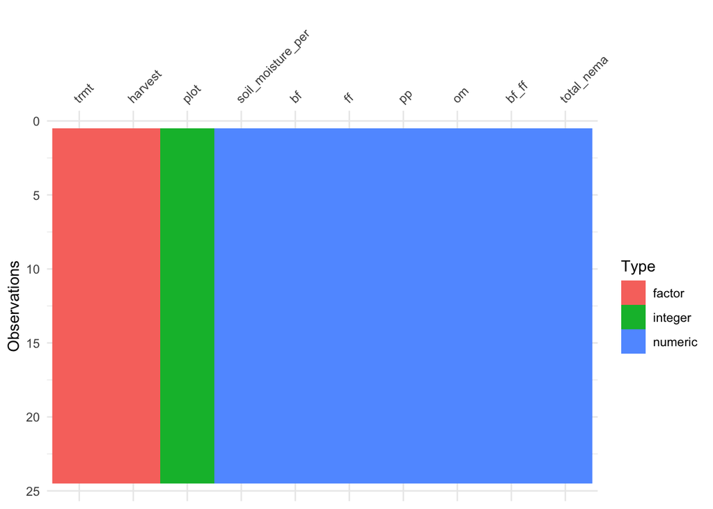

```r
#missing data assessment
vis_dat(nema_dens)
```

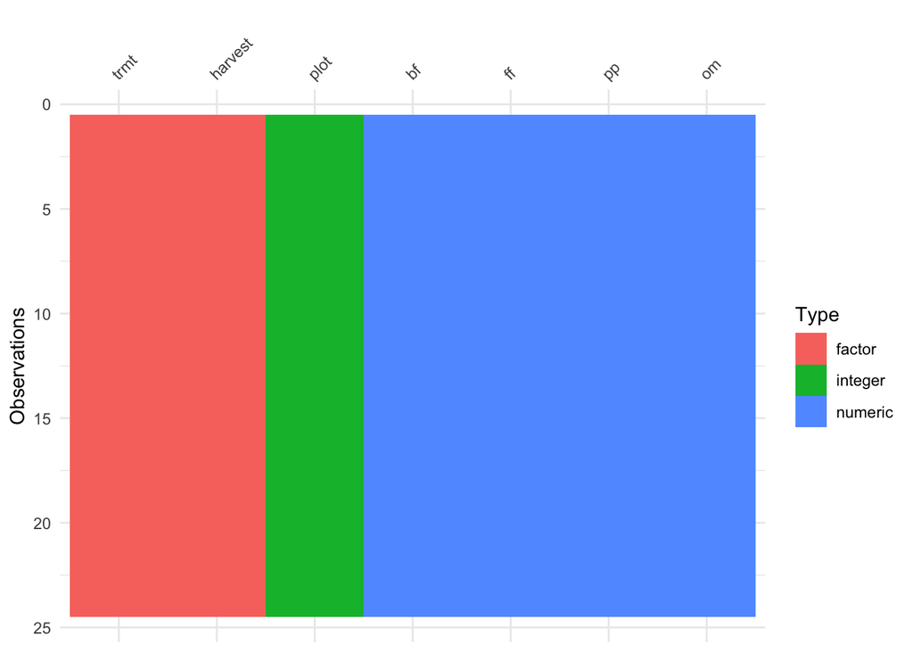

```r
vis_dat(nema_prop)
```

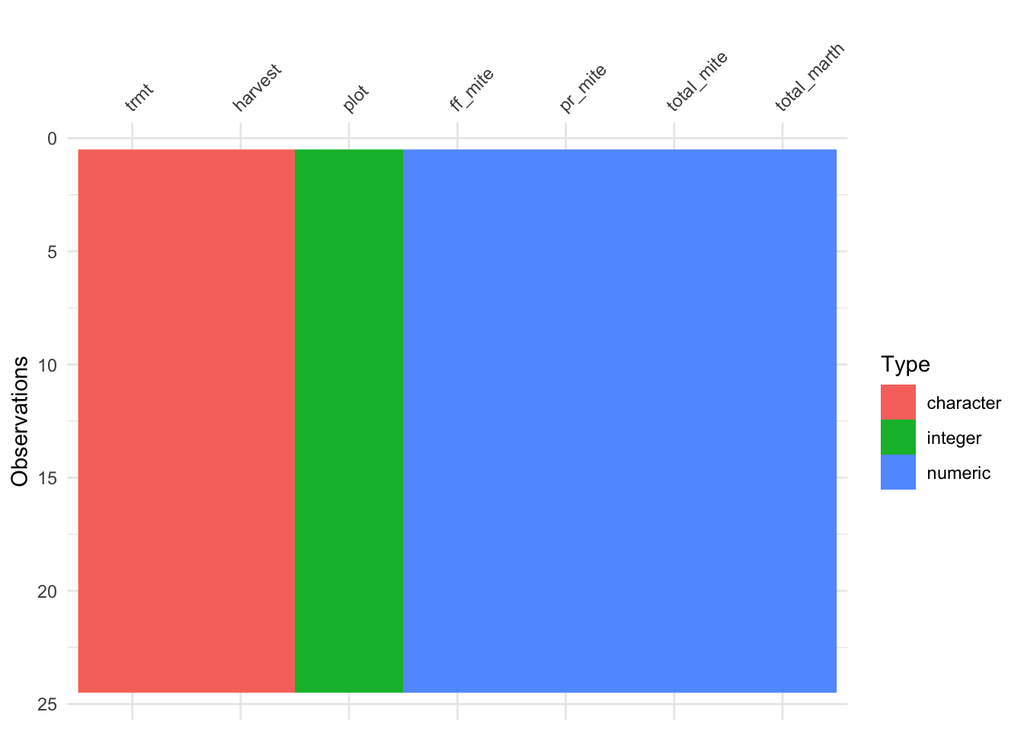

```r
vis_dat(mite_dens)
```

```r
#no missing data

#checking data for irregularities
dim(nema_dens); dim(nema_prop); dim(mite_dens) #all seem fine
```

```
## [1] 24 10
```

```
## [1] 24  7
```

```
## [1] 24  7
```

```r
str(nema_dens); str(nema_prop); str(mite_dens) #all cols coded correctly
```

```
## tibble [24 × 10] (S3: tbl_df/tbl/data.frame)
##  $ plot             : int [1:24] 1 2 3 4 5 6 7 8 9 10 ...
##  $ trmt             : Factor w/ 2 levels "Ex","Gh": 2 1 2 1 2 1 1 2 2 1 ...
##  $ harvest          : Factor w/ 2 levels "F","I": 2 2 2 2 2 2 2 2 2 2 ...
##  $ soil_moisture_per: num [1:24] 4 4.98 5.48 3.7 4.31 ...
##  $ bf               : num [1:24] 12064 7530 12335 11075 6925 ...
##  $ ff               : num [1:24] 4752 7949 11371 14095 5029 ...
##  $ pp               : num [1:24] 3534 2092 6553 6645 1237 ...
##  $ om               : num [1:24] 2193 1883 5589 4833 2391 ...
##  $ bf_ff            : num [1:24] 2.538 0.947 1.085 0.786 1.377 ...
##  $ total_nema       : num [1:24] 24371 20918 38547 40272 16489 ...
```

```
## tibble [24 × 7] (S3: tbl_df/tbl/data.frame)
##  $ plot   : int [1:24] 1 2 3 4 5 6 7 8 9 10 ...
##  $ trmt   : Factor w/ 2 levels "Ex","Gh": 2 1 2 1 2 1 1 2 2 1 ...
##  $ harvest: Factor w/ 2 levels "F","I": 2 2 2 2 2 2 2 2 2 2 ...
##  $ bf     : num [1:24] 0.495 0.36 0.32 0.275 0.42 0.55 0.62 0.36 0.415 0.42 ...
##  $ ff     : num [1:24] 0.195 0.38 0.295 0.35 0.305 0.245 0.235 0.35 0.41 0.285 ...
##  $ pp     : num [1:24] 0.145 0.1 0.17 0.165 0.075 0.115 0.045 0.17 0.1 0.16 ...
##  $ om     : num [1:24] 0.09 0.09 0.145 0.12 0.145 0.035 0.03 0.05 0.025 0.07 ...
```

```
## tibble [24 × 7] (S3: tbl_df/tbl/data.frame)
##  $ plot       : int [1:24] 1 2 3 4 5 6 7 8 9 10 ...
##  $ trmt       : chr [1:24] "Gh" "Ex" "Gh" "Ex" ...
##  $ harvest    : chr [1:24] "I" "I" "I" "I" ...
##  $ ff_mite    : num [1:24] 965 445 866 367 418 ...
##  $ pr_mite    : num [1:24] 87.5 121.5 135.1 102.9 88.3 ...
##  $ total_mite : num [1:24] 1053 567 1001 470 507 ...
##  $ total_marth: num [1:24] 1068 642 1011 621 553 ...
```

```r
head(nema_dens); tail(nema_dens) #look as expected
```

```
## # A tibble: 6 x 10
##    plot trmt  harvest soil_moisture_p…     bf     ff    pp    om bf_ff
##   <int> <fct> <fct>              <dbl>  <dbl>  <dbl> <dbl> <dbl> <dbl>
## 1     1 Gh    I                   4.00 12064.  4752. 3534. 2193. 2.54
## 2     2 Ex    I                   4.98  7530.  7949. 2092. 1883. 0.947
## 3     3 Gh    I                   5.48 12335. 11371. 6553. 5589. 1.08
## 4     4 Ex    I                   3.70 11075. 14095. 6645. 4833. 0.786
## 5     5 Gh    I                   4.31  6925.  5029. 1237. 2391. 1.38
## 6     6 Ex    I                   3.91 20668.  9207. 4321. 1315. 2.24
## # … with 1 more variable: total_nema <dbl>
```

```
## # A tibble: 6 x 10
##    plot trmt  harvest soil_moisture_per    bf    ff    pp    om bf_ff total_nema
##   <int> <fct> <fct>               <dbl> <dbl> <dbl> <dbl> <dbl> <dbl>      <dbl>
## 1     7 Ex    F                    7.69 5752. 2767.  977.  814. 2.08      10853.
## 2     8 Gh    F                    8.98 3347.  816. 1224. 2490. 4.1        8163.
## 3     9 Gh    F                    6.84 2483. 2215.  570.  705. 1.12       6712.
## 4    10 Ex    F                    8.08 1780. 2350. 1602.  855. 0.758      7121.
## 5    11 Gh    F                    7.73 4421. 1888. 1105. 1243. 2.34       9210.
## 6    12 Ex    F                    7.01 5062. 2503. 1224. 1446. 2.02      11124.
```

```r
head(nema_prop); tail(nema_prop) #look as expected
```

```
## # A tibble: 6 x 7
##    plot trmt  harvest    bf    ff    pp    om
##   <int> <fct> <fct>   <dbl> <dbl> <dbl> <dbl>
## 1     1 Gh    I       0.495 0.195 0.145 0.09
## 2     2 Ex    I       0.36  0.38  0.1   0.09
## 3     3 Gh    I       0.32  0.295 0.17  0.145
## 4     4 Ex    I       0.275 0.35  0.165 0.12
## 5     5 Gh    I       0.42  0.305 0.075 0.145
## 6     6 Ex    I       0.55  0.245 0.115 0.035
```

```
## # A tibble: 6 x 7
##    plot trmt  harvest    bf    ff    pp    om
##   <int> <fct> <fct>   <dbl> <dbl> <dbl> <dbl>
## 1     7 Ex    F       0.53  0.255 0.09  0.075
## 2     8 Gh    F       0.41  0.1   0.15  0.305
## 3     9 Gh    F       0.37  0.33  0.085 0.105
## 4    10 Ex    F       0.25  0.33  0.225 0.12
## 5    11 Gh    F       0.48  0.205 0.12  0.135
## 6    12 Ex    F       0.455 0.225 0.11  0.13
```

```r
head(mite_dens); tail(mite_dens) #look as expected
```

```
## # A tibble: 6 x 7
##    plot trmt  harvest ff_mite pr_mite total_mite total_marth
##   <int> <chr> <chr>     <dbl>   <dbl>      <dbl>       <dbl>
## 1     1 Gh    I          965.    87.5      1053.       1068.
## 2     2 Ex    I          445.   121.        567.        642.
## 3     3 Gh    I          866.   135.       1001.       1011.
## 4     4 Ex    I          367.   103.        470.        621.
## 5     5 Gh    I          418.    88.3       507.        553.
## 6     6 Ex    I          235.    19.6       255.        266.
```

```
## # A tibble: 6 x 7
##    plot trmt  harvest ff_mite pr_mite total_mite total_marth
##   <int> <chr> <chr>     <dbl>   <dbl>      <dbl>       <dbl>
## 1     7 Ex    F         3857.    65.7      3923.       3945.
## 2     8 Gh    F          663.    35.0       698.        742.
## 3     9 Gh    F          240.   131.        371.        477.
## 4    10 Ex    F          684.    39.2       723.        756.
## 5    11 Gh    F          561.    49.2       610.        651.
## 6    12 Ex    F          557.    33.4       590.        612.
```

```r
map(nema_dens[4:10],range)
```

```
## $soil_moisture_per
## [1]  3.573718 10.580838
##
## $bf
## [1]  1780.329 20667.904
##
## $ff
## [1]   816.2903 14095.3659
##
## $pp
## [1]  403.3967 6644.9582
##
## $om
## [1]  673.7558 5589.3032
##
## $bf_ff
## [1] 0.7575758 4.1000000
##
## $total_nema
## [1]  6711.584 40272.474
```

```r
map(nema_prop[4:7],range)
```

```
## $bf
## [1] 0.25 0.62
##
## $ff
## [1] 0.10 0.41
##
## $pp
## [1] 0.045 0.225
##
## $om
## [1] 0.025 0.325
```

```r
map(mite_dens[4:7],range)
```

```
## $ff_mite
## [1]  235.2086 3857.3627
##
## $pr_mite
## [1]  19.60071 180.55950
##
## $total_mite
## [1]  254.8093 3923.0199
##
## $total_marth
## [1]  266.0097 3944.9056
```

```r
#no irregularities detected
```

No missing data or irregularities detected.

The three tibbles (i.e., nematode densities, nematode proportions, mite densities) were saved as separate .csv files.

```r
#export tibbles as a .csv
write_csv(nema_dens,here("data","tidy_data","nema_densities.csv"))
write_csv(nema_prop,here("data","tidy_data","nema_proportions.csv"))
write_csv(mite_dens,here("data","tidy_data","mite_densities.csv"))
```

## **Conclusion**

The data cleaning, wrangling, processing steps shown above yielded the following files: 1) tidy_gh_data.csv, 2) ag_plant_biomass.csv, 3) bg_plant_biomass.csv, 4) s_r_data.csv, 5) nema_densities.csv, 6) nema_proportions_csv, and 7) mite_densities. These files are in a tidy format, have correct column classes, and no excessive missingness (beyond what was expected from raw files). These datasets could be easily read into R using read_csv() from the readr package. The data are in the appropriate format for exploration (e.g., visualization, summary statistics) and/or statistical analysis because columns are properly coded and tibbles are tidy (i.e., one variable per column, one observation per row, and one table per type of data). The plot variable, which exists in all tibbles, enables one to analyze data from multiple tibbles using join statements.